# Investigative Report: Supporting Question #6

Yashpal Saini

Group: Breaking Lease – How We Met Your Landlord

Research Topic: New York City housing risk: Complaints & Code Violations

December 18, 2025

## **Is there spatial clustering of unresolved 311 housing complaints in low-income areas?**

This section presents an investigative analysis addressing Supporting Question #6. Using NYC 311 housing complaint data and census tract–level income information, the goal is to determine whether unresolved complaints exhibit statistically significant spatial clustering, particularly within lower-income neighborhoods.

# Motivation and context

NYC 311 is the City’s main channel for non-emergency quality‑of‑life and housing concerns. Housing-related complaints—such as lack of heat, mold, pests, unsafe conditions, and building maintenance failures—are especially important because unresolved problems can directly affect residents’ health and safety.

A key concern is not only **how many** complaints exist, but **where unresolved complaints persist**. If unresolved complaints are clustered in specific neighborhoods, that suggests concentrated service backlogs, structural barriers to resolution, or unequal enforcement capacity. This investigation therefore asks whether unresolved 311 housing complaints are randomly distributed or spatially concentrated—and whether the strongest clustering appears in lower-income areas.

# Research question

**Is there statistically significant spatial clustering of unresolved 311 housing complaints in low-income areas of New York City?**

This question is evaluated using spatial autocorrelation techniques and income stratification so the conclusion is supported by statistical evidence rather than visual impression alone.

# Data sources and preparation

This analysis integrates two tract-level datasets:

- **NYC 311 Housing Complaints (2023)**  
  Filtered to include housing-related complaint categories. A status flag was used to isolate complaints that remained **unresolved** in the study period.
- **American Community Survey (ACS) Income Data (2023)**  
  Median household income was used to classify each census tract into **income quintiles** (Q1 = lowest income … Q5 = highest income).

## Key preparation steps

The work required standardizing and aligning the data so tract‑level comparisons were valid:

- **Filter** the 311 dataset to the relevant housing complaint scope.
- **Define unresolved complaints** (consistent rule across the dataset).
- **Aggregate** complaints to the **census tract** level (counts or rates).
- **Join** tract-level income data to each tract.
- **Create income quintiles** to compare patterns across socioeconomic groups.
- **Validate spatial alignment** (tract geometries and IDs match the analysis units).

> This report focuses on the investigative logic and results. Code is intentionally hidden to keep the website clean and presentation-ready.

# Methodology

To detect localized spatial clustering, the analysis uses **Local Moran’s I (LISA)**.

## Why Local Moran’s I?

Local Moran’s I is designed to identify *where* statistically significant clustering occurs. Instead of producing a single “citywide” autocorrelation value, it highlights specific neighborhoods that are part of a cluster or are spatial outliers.

Each tract is classified into cluster types:

- **High–High (hotspot):** high unresolved complaints surrounded by high unresolved complaints
- **Low–Low (cold spot):** low unresolved complaints surrounded by low unresolved complaints
- **High–Low / Low–High (outliers):** a tract differs from its neighbors
- **Not significant:** no detectable localized clustering at the chosen significance threshold

## Income stratification

To assess whether clustering is associated with income, the same hotspot logic is examined by **income quintile (Q1–Q5)**. This allows a direct comparison of clustering intensity across socioeconomic levels.

# Results and visual evidence

## Citywide hotspot patterns

Below is the citywide hotspot map for unresolved 311 housing complaints.

Hotspot Map of Unresolved 311 Housing Complaints (2023)

Local Moran’s I (LISA) clusters at the census tract level

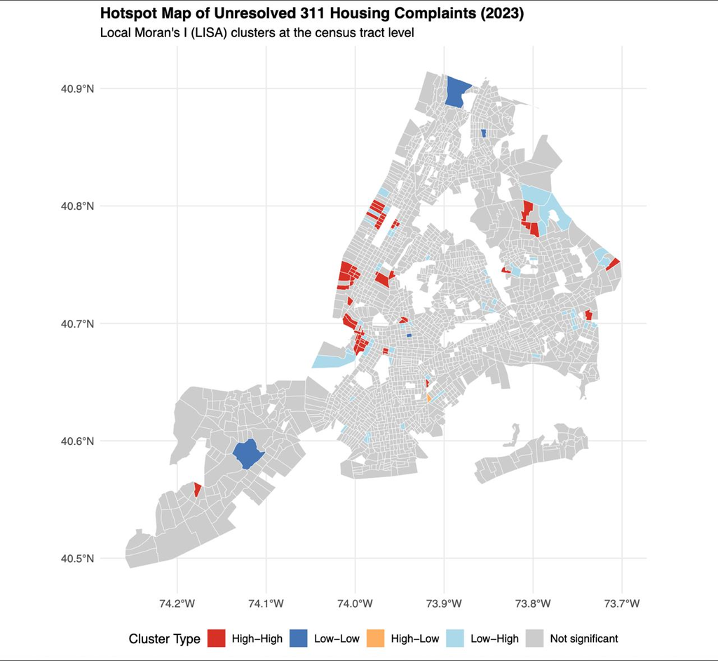

[output not shown]

### Interpretation

This map supports three core takeaways:

- **Unresolved housing complaints are not randomly distributed.** The presence of High–High clusters indicates meaningful spatial concentration.
- **Hotspots are localized.** Many tracts are not significant, implying the pattern is not “everywhere at once,” but concentrated in specific areas.
- **Cold spots also exist.** Low–Low clusters suggest some neighborhoods consistently experience fewer unresolved housing complaints.

In an operational setting, these clusters would be strong candidates for deeper investigation: what complaint types dominate there, what the responsible agencies are, and whether staffing or enforcement resources match the burden.

## Clustering by income quintile

The figure below breaks clustering patterns out by tract income quintile.

Spatial Clustering of Unresolved Complaints by Income Quintile (2023)

Facets show how clustering patterns differ across low vs high income areas

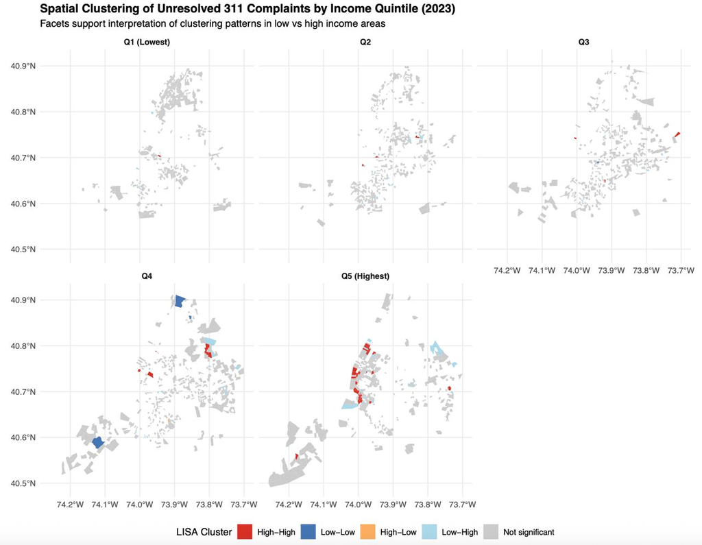

[output not shown]

### Interpretation

# Key findings

### Why spatial clustering matters for housing equity

Identifying spatial clustering of unresolved housing complaints is important because housing conditions are not merely individual problems; they are often shaped by neighborhood-level structures such as landlord practices, housing stock age, enforcement intensity, and political influence. When unresolved complaints cluster geographically, it suggests that residents in certain areas may face systematic barriers to achieving safe and habitable housing conditions.

In lower-income neighborhoods, residents may have fewer resources to pursue follow-up actions, legal remedies, or private repairs. As a result, unresolved complaints can accumulate over time rather than being resolved promptly. Spatial clustering analysis helps move the discussion beyond anecdotal evidence by providing statistical support for these patterns.

From an equity perspective, persistent clusters of unresolved complaints raise concerns about whether municipal services are equitably reaching all communities. If unresolved complaints are disproportionately concentrated in lower-income areas, this may reflect unequal enforcement, resource constraints, or structural disadvantages rather than differences in reporting behavior alone.

### Distinguishing reporting behavior from service outcomes

One potential concern when analyzing 311 data is whether observed patterns reflect differences in reporting behavior rather than differences in service outcomes. Residents in some neighborhoods may be more likely to report issues, while others may underreport due to distrust, language barriers, or lack of awareness.

However, this investigation focuses specifically on **unresolved complaints**, not total complaint volume. By conditioning the analysis on complaints that have already been reported, the study shifts attention from reporting propensity to service follow-through. Spatial clustering of unresolved cases therefore provides evidence about where the resolution process itself may be breaking down.

Additionally, the presence of Low–Low clusters suggests that not all areas with high reporting necessarily experience poor outcomes. This further supports the interpretation that unresolved complaint clustering reflects differences in resolution dynamics rather than reporting alone.

### Interpreting High–High clusters as persistent problem areas

High–High clusters in Local Moran’s I analysis indicate areas where unresolved housing complaints are consistently high and surrounded by similarly high neighboring tracts. These clusters are especially important because they suggest persistence rather than isolated failure.

In practical terms, High–High clusters may indicate neighborhoods with aging housing stock, repeated landlord noncompliance, or enforcement bottlenecks that prevent timely resolution. When these clusters overlap with lower-income areas, they raise questions about whether current policy tools are sufficient to address entrenched housing quality issues.

Rather than treating each complaint independently, agencies could use cluster information to identify neighborhoods requiring targeted intervention strategies. This might include proactive inspections, coordinated enforcement actions, or increased tenant outreach.

# Limitations

Even strong spatial results should be interpreted carefully:

- **Unresolved does not always mean neglected.** Some cases may be delayed due to access, legal processes, or complexity.
- **311 reflects reporting behavior**, not the full universe of housing problems.
- **Aggregation can hide within-tract variation.** A tract may include heterogeneous blocks.
- **Income is not the only driver.** Housing stock age, landlord practices, enforcement patterns, and demographic factors may also contribute.

# Practical implications

From a policy and service-delivery perspective, these results suggest the value of **place-based targeting**:

- Prioritize inspection and enforcement resources in persistent High–High hotspots.
- Track whether hotspot tracts experience longer closure times or repeated complaints.
- Pair enforcement with preventive support (tenant resources, landlord compliance programs) in high-burden areas.
- Use hotspot monitoring as an early warning system for emerging neighborhood-level housing distress.

# Conclusion

# Next steps

If extended beyond this question, the next steps would include:

- Modeling **time-to-resolution** (not just unresolved status)
- Identifying which **complaint subtypes** drive hotspot formation
- Comparing hotspots across **multiple years** to test persistence
- Examining agency-level differences in closure behavior across hotspot vs non-hotspot tracts